# Tidyverse

## Tidyverse: Arrange

### Arrange

- It sorts a table based on a variable

```r
gapminder %>% arrange(gdpPercap)
```

```
# A tibble: 1,704 × 6
   country          continent  year lifeExp      pop gdpPercap
   <fct>            <fct>     <int>   <dbl>    <int>     <dbl>
 1 Congo, Dem. Rep. Africa     2002    45.0 55379852      241.
 2 Congo, Dem. Rep. Africa     2007    46.5 64606759      278.
 3 Lesotho          Africa     1952    42.1   748747      299.
 4 Guinea-Bissau    Africa     1952    32.5   580653      300.
 5 Congo, Dem. Rep. Africa     1997    42.6 47798986      312.
 6 Eritrea          Africa     1952    35.9  1438760      329.
 7 Myanmar          Asia       1952    36.3 20092996      331
 8 Lesotho          Africa     1957    45.0   813338      336.
 9 Burundi          Africa     1952    39.0  2445618      339.
10 Eritrea          Africa     1957    38.0  1542611      344.
# … with 1,694 more rows
```

### Arrange

- It sorts a table based on a variable: Sorting in descending order

```r
gapminder %>% arrange(desc(gdpPercap))
```

```
# A tibble: 1,704 × 6
   country   continent  year lifeExp     pop gdpPercap
   <fct>     <fct>     <int>   <dbl>   <int>     <dbl>
 1 Kuwait    Asia       1957    58.0  212846   113523.
 2 Kuwait    Asia       1972    67.7  841934   109348.
 3 Kuwait    Asia       1952    55.6  160000   108382.
 4 Kuwait    Asia       1962    60.5  358266    95458.
 5 Kuwait    Asia       1967    64.6  575003    80895.
 6 Kuwait    Asia       1977    69.3 1140357    59265.
 7 Norway    Europe     2007    80.2 4627926    49357.
 8 Kuwait    Asia       2007    77.6 2505559    47307.
 9 Singapore Asia       2007    80.0 4553009    47143.
10 Norway    Europe     2002    79.0 4535591    44684.
# … with 1,694 more rows
```

### Filtering then arranging

```r
gapminder %>%
  filter(year == 2007) %>% arrange(desc(gdpPercap))
```

```
# A tibble: 142 × 6
   country          continent  year lifeExp       pop gdpPercap
   <fct>            <fct>     <int>   <dbl>     <int>     <dbl>
 1 Norway           Europe     2007    80.2   4627926    49357.
 2 Kuwait           Asia       2007    77.6   2505559    47307.
 3 Singapore        Asia       2007    80.0   4553009    47143.
 4 United States    Americas   2007    78.2 301139947    42952.
 5 Ireland          Europe     2007    78.9   4109086    40676.
 6 Hong Kong, China Asia       2007    82.2   6980412    39725.
 7 Switzerland      Europe     2007    81.7   7554661    37506.
 8 Netherlands      Europe     2007    79.8  16570613    36798.
 9 Canada           Americas   2007    80.7  33390141    36319.
10 Iceland          Europe     2007    81.8    301931    36181.
# … with 132 more rows
```

## Tidyverse: Mutate

### Mutate

- Using mutate to change a variable

```r
gapminder %>%
  mutate(pop = pop / 1000000)
```

```
# A tibble: 1,704 × 6
   country     continent  year lifeExp   pop gdpPercap
   <fct>       <fct>     <int>   <dbl> <dbl>     <dbl>
 1 Afghanistan Asia       1952    28.8  8.43      779.
 2 Afghanistan Asia       1957    30.3  9.24      821.
 3 Afghanistan Asia       1962    32.0 10.3       853.
 4 Afghanistan Asia       1967    34.0 11.5       836.
 5 Afghanistan Asia       1972    36.1 13.1       740.
 6 Afghanistan Asia       1977    38.4 14.9       786.
 7 Afghanistan Asia       1982    39.9 12.9       978.
 8 Afghanistan Asia       1987    40.8 13.9       852.
 9 Afghanistan Asia       1992    41.7 16.3       649.
10 Afghanistan Asia       1997    41.8 22.2       635.
# … with 1,694 more rows
```

### Mutate

- Using mutate to add a new variable

```r
gapminder %>%
  mutate(gdp = gdpPercap * pop)
```

```
# A tibble: 1,704 × 7
   country     continent  year lifeExp      pop gdpPercap          gdp
   <fct>       <fct>     <int>   <dbl>    <int>     <dbl>        <dbl>
 1 Afghanistan Asia       1952    28.8  8425333      779.  6567086330.
 2 Afghanistan Asia       1957    30.3  9240934      821.  7585448670.
 3 Afghanistan Asia       1962    32.0 10267083      853.  8758855797.
 4 Afghanistan Asia       1967    34.0 11537966      836.  9648014150.
 5 Afghanistan Asia       1972    36.1 13079460      740.  9678553274.
 6 Afghanistan Asia       1977    38.4 14880372      786. 11697659231.
 7 Afghanistan Asia       1982    39.9 12881816      978. 12598563401.
 8 Afghanistan Asia       1987    40.8 13867957      852. 11820990309.
 9 Afghanistan Asia       1992    41.7 16317921      649. 10595901589.
10 Afghanistan Asia       1997    41.8 22227415      635. 14121995875.
# … with 1,694 more rows
```

### Combining verbs

- mutate, filter, arrange

```r
gapminder %>%
  mutate(gdp = gdpPercap * pop) %>% filter(year == 2007) %>% arrange(desc(gdp))
```

```
# A tibble: 142 × 7
   country        continent  year lifeExp        pop gdpPercap     gdp
   <fct>          <fct>     <int>   <dbl>      <int>     <dbl>   <dbl>
 1 United States  Americas   2007    78.2  301139947    42952. 1.29e13
 2 China          Asia       2007    73.0 1318683096     4959. 6.54e12
 3 Japan          Asia       2007    82.6  127467972    31656. 4.04e12
 4 India          Asia       2007    64.7 1110396331     2452. 2.72e12
 5 Germany        Europe     2007    79.4   82400996    32170. 2.65e12
 6 United Kingdom Europe     2007    79.4   60776238    33203. 2.02e12
 7 France         Europe     2007    80.7   61083916    30470. 1.86e12
 8 Brazil         Americas   2007    72.4  190010647     9066. 1.72e12
 9 Italy          Europe     2007    80.5   58147733    28570. 1.66e12
10 Mexico         Americas   2007    76.2  108700891    11978. 1.30e12
# … with 132 more rows
```

### The summarize verb

- Functions you can use for summarizing
  - mean
  - sum
  - median
  - min
  - max

```r
gapminder %>%
  summarize(meanLifeExp = mean(lifeExp))
```

```
# A tibble: 1 × 1
  meanLifeExp
        <dbl>
1        59.5
```

### The summarize verb

-Summarizing one year

```r
gapminder %>%
  filter(year == 2007) %>% summarize(meanLifeExp = mean(lifeExp))
```

```
# A tibble: 1 × 1
  meanLifeExp
        <dbl>
1        67.0
```

### The summarize verb

-Summarizing one year

```r
gapminder %>%
  filter(year == 2007) %>%
  summarize(meanLifeExp = mean(lifeExp), totalPop = sum(pop))
```

```
# A tibble: 1 × 2
  meanLifeExp   totalPop
        <dbl>      <dbl>
1        67.0 6251013179
```

### The group_by verb

- Summarizing by year

```r
gapminder %>%
  group_by(year) %>%
  summarize(meanLifeExp = mean(lifeExp), totalPop = sum(pop))
```

```
# A tibble: 12 × 3
    year meanLifeExp   totalPop
   <int>       <dbl>      <dbl>
 1  1952        49.1 2406957150
 2  1957        51.5 2664404580
 3  1962        53.6 2899782974
 4  1967        55.7 3217478384
 5  1972        57.6 3576977158
 6  1977        59.6 3930045807
 7  1982        61.5 4289436840
 8  1987        63.2 4691477418
 9  1992        64.2 5110710260
10  1997        65.0 5515204472
11  2002        65.7 5886977579
12  2007        67.0 6251013179
```

### The group_by verb

- Summarizing by continent

```r
gapminder %>%
    group_by(year, continent) %>%
    summarize(totalPop = sum(pop),
    meanLifeExp = mean(lifeExp))
```

```
# A tibble: 60 × 4
# Groups:   year [12]
    year continent   totalPop meanLifeExp
   <int> <fct>          <dbl>       <dbl>
 1  1952 Africa     237640501        39.1
 2  1952 Americas   345152446        53.3
 3  1952 Asia      1395357351        46.3
 4  1952 Europe     418120846        64.4
 5  1952 Oceania     10686006        69.3
 6  1957 Africa     264837738        41.3
 7  1957 Americas   386953916        56.0
 8  1957 Asia      1562780599        49.3
 9  1957 Europe     437890351        66.7
10  1957 Oceania     11941976        70.3
# … with 50 more rows
```

### Visualizing with ggplot2

- https://ggplot2.tidyverse.org/
- Summarizing by continent

```r
library(ggplot2)

gapminder_2007 <- gapminder %>% filter(year == 2007)

gapminder_2007
```

```
# A tibble: 142 × 6
   country     continent  year lifeExp       pop gdpPercap
   <fct>       <fct>     <int>   <dbl>     <int>     <dbl>
 1 Afghanistan Asia       2007    43.8  31889923      975.
 2 Albania     Europe     2007    76.4   3600523     5937.
 3 Algeria     Africa     2007    72.3  33333216     6223.
 4 Angola      Africa     2007    42.7  12420476     4797.
 5 Argentina   Americas   2007    75.3  40301927    12779.
 6 Australia   Oceania    2007    81.2  20434176    34435.
 7 Austria     Europe     2007    79.8   8199783    36126.
 8 Bahrain     Asia       2007    75.6    708573    29796.
 9 Bangladesh  Asia       2007    64.1 150448339     1391.
10 Belgium     Europe     2007    79.4  10392226    33693.
# … with 132 more rows
```

### Visualizing with ggplot2

- Summarizing by continent

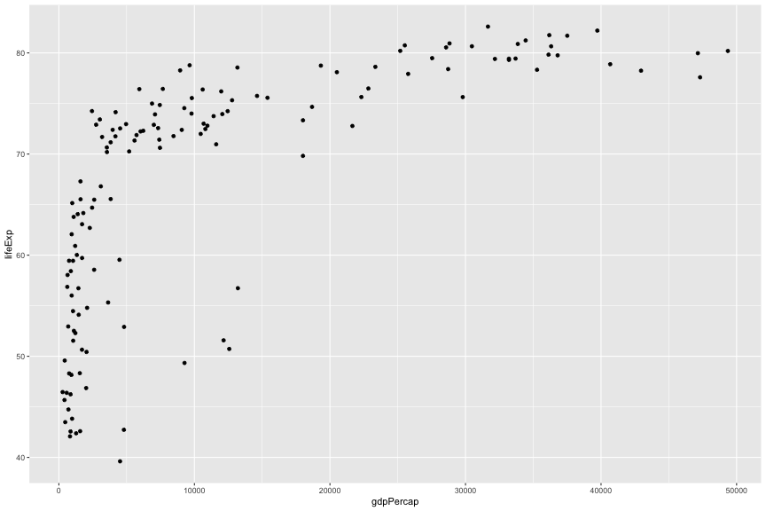

```r
ggplot(gapminder_2007,
       aes(x = gdpPercap, y = lifeExp)) +
          geom_point()
```

### Visualizing with ggplot2

- Summarizing by continent

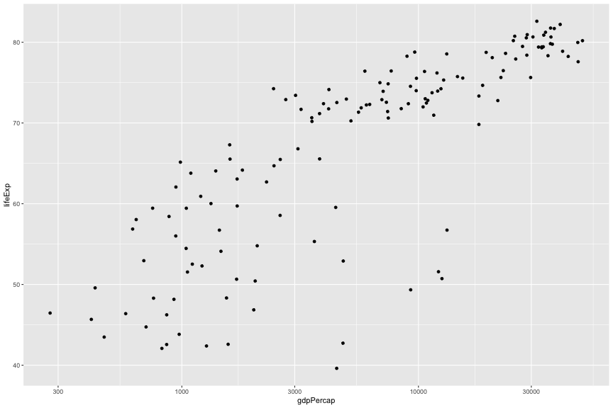

```r
ggplot(gapminder_2007,
       aes(x = gdpPercap, y = lifeExp)) +
          geom_point() + scale_x_log10()
```

### Visualizing with ggplot2

- The color aesthetic

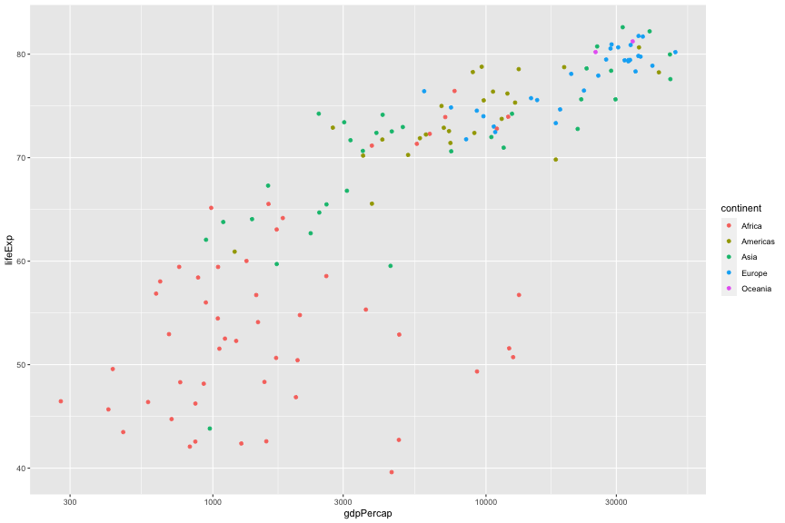

```r
ggplot(gapminder_2007,
       aes(x = gdpPercap, y = lifeExp, color = continent)) +
          geom_point() + scale_x_log10()
```

### Visualizing with ggplot2

- The size aesthestic

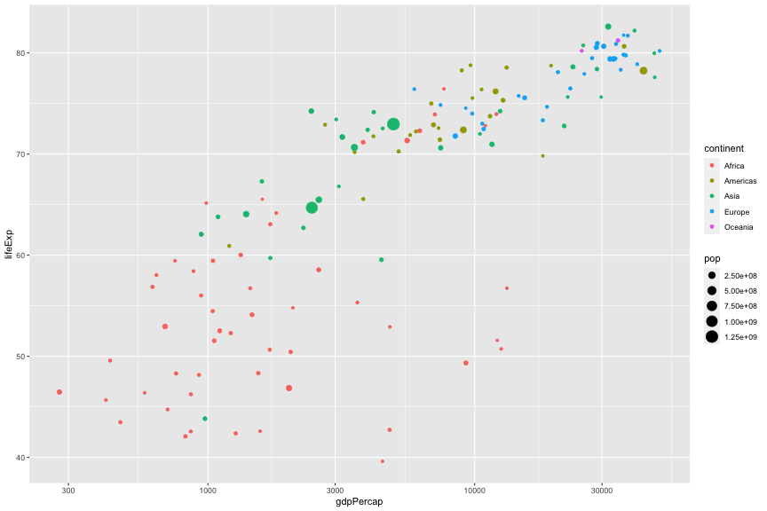

```r
ggplot(gapminder_2007,
       aes(x = gdpPercap, y = lifeExp, color = continent, size = pop)) +
          geom_point() + scale_x_log10()
```

### Visualizing with ggplot2

- Faceting

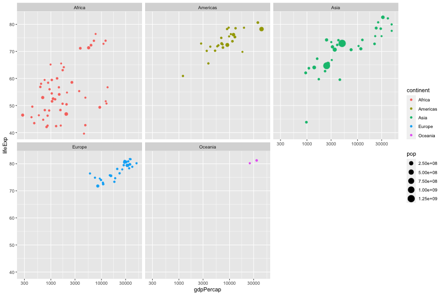

```r
ggplot(gapminder_2007,
       aes(x = gdpPercap, y = lifeExp, color = continent, size = pop)) +
          geom_point() + scale_x_log10() +
            facet_wrap(~ continent)
```

### Reading files

- Reading files